# Data Processes Project Report

Carlos Sánchez Marín

Álvaro Arranz Domínguez

Angel González López

Daniel Saiz González

12/20/2019

### Abstract

This project tries to answer a new question which appreared while we were working on the ones proposed a months ago, **How much could make a professional player from other big leagues in the NBA?**

To answer this question, we modeled a Machine Learning model using the **Random Forest** algorithm. We obtained a quite satisfactory result taking into account we only have data from the last season, and the model could be improved introducing more data, not only related with NBA games but also with everything surrounding the teams and the league.

To develop this project we used R with several libraries like **ggplot2**, **dplyr** and **caret**, covered by the book used in the lectures; but also we used patchwork to help us with the graphs composition.

### Introduction and Related Work

On the project proposal we formulated 3 different questions. We decide to answer the second one about the gap between east and west conferences.

One of our member followed for years the NBA and during that period of time the Western conference teams ruled the league with Golden State Warriors on the head. Only the Cleveland Cavaliers and Miami Heat, thanks to LeBron James could fight against the best western team. During the last 8 seasons, LeBron James won 4 rings (3 with Miami Heats and 1 with Cleveland Cavaliers) and played 7 finals.

LeBron James is one of the best players in the NBA history, and he is able to lead a whole team to the victory almost by himself, but this is not the case with any other player of the league at this moment. LeBron moved to Los Angeles Lakers on the last season, and the project wasn’t complete, which is one of the reasons to select the season 2018/2019 to avoid an outlier on the eastern team where LeBron is playing.

To check if we were sure about our assumptions, we loaded the Match Statistics Dataset and performed several transformations to retrieve the data we wanted.

| Conference | Wins |
| --- | --- |
| EAST | 198 |
| WEST | 252 |

It seems like the gap between the West and the East is still there, but with this simple table we cannot be sure the data is not biased by low performing teams. To check this we plotted the wins against teams of the same conference and teams of the other, clustering the results by conferences. The script which generates the following chart can be found [here](https://github.com/AlmaProcesses/NBA_Project/blob/master/scripts/question_2.R)

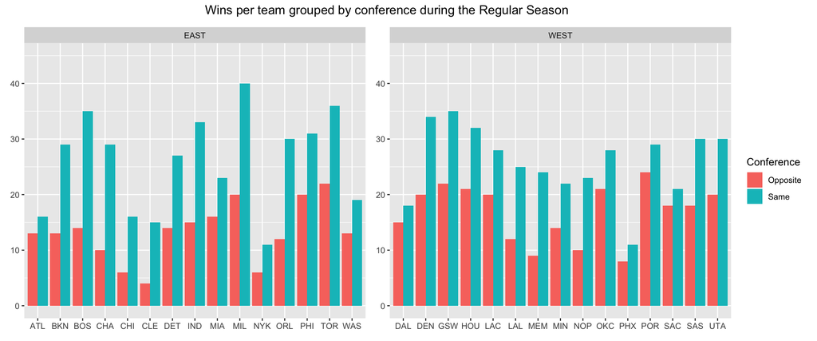

Anyways, we have nothing to do with this information in order to develop a Machine Learning model, so we decided to change our question to the one stated at the introduction.

To help us with the selection of the new question, we looked for information and found projects like the following ones:

- [The Talent Difference Between the West and Eastern Conferences](https://thegruelingtruth.com/basketball/the-talent-difference-between-the-west-and-eastern-conferences/)
- [COMPETITIVE BALANCE IN THE NBA: Comparative analysis of Eastern and Western Conferences](http://pagines.uab.cat/appliedeconomics/sites/pagines.uab.cat.appliedeconomics/files/Brosed,%20M._paper.pdf)
- [NBA Predictions for the 2019-2020 Season](https://www.sbnation.com/nba/2019/10/22/20899122/nba-predictions-2019-2020-season-mvp-championship-nba-finals-lakers-clippers)
- [2019-20 NBA Predictions](https://projects.fivethirtyeight.com/2020-nba-predictions/)
- [How to predict NBA Player Salaries With Data Science](https://medium.com/better-programming/predicting-nba-player-salary-with-data-science-c5702caa3f2e)

### Exploratory Data Analysis

#### Datasets

The dataset has been produced using the R package [nbastatR](http://asbcllc.com/nbastatR/), which parses information from the official [NBA API](https://stats.nba.com/) and different pages containing NBA historic data like [Hoopshype.com](https://hoopshype.com/). There are two different datasets:

##### Match Statistics Dataset

This dataset contains statistics about the NBA games during the 2018-19 season.

This dataset consists of one csv file. It’s named regularseason1819_games.csv. It has 2460 observations and 47 features.

| Column | Type | Description |
| --- | --- | --- |
| `yearSeason` | num | The year when the statistics were taken |
| `slugSeason` | num | The season of the match |
| `slugLeague` | chr | League name abbreviation |
| `typeSeason` | chr | Type of season (always `Regular Season`) |
| `dateGame` | date | Date the match was played |
| `idGame` | num | Id of the match on the NBA API |
| `numberGameTeamSeason` | num | Match order for the team |
| `nameTeam` | num | Name of the team |
| `idTeam` | num | Id of the team on the NBA API |
| `isB2B` | logi | The match was a back to back |
| `isB2BFirst` | logi | The match was the first back to back |
| `isB2BSecond` | logi | The match was the second back to back |
| `locationGame` | chr | Location where the match was played |
| `slugMatchup` | chr | Abbreviation of the match |
| `slugTeam` | chr | Abbreviation of the team |
| `countDaysRestTeam` | num | Days the team had for resting before the match |
| `countDaysNextGameTeam` | num | Days before the next team’s match |
| `slugOpponent` | chr | Abbreviation of the opponent team |
| `slugTeamWinner` | chr | Abbreviation of the winner team |
| `slugTeamLoser` | chr | Abbreviation of the defeated team |
| `outcomeGame` | chr | The abbreviation of the result (`W\|L`) |
| `isWin` | logi | True if the team won the match |
| `fgmTeam` | num | Field goals made by the team |
| `fgaTeam` | num | Field goals attempted by the team |
| `pctFGTeam` | num | % of field goals made vs attempted |
| `fg3mTeam` | num | 3-pts field goals made by the team |
| `fg3aTeam` | num | 3-pts field goals attempted by the team |
| `pctFG3Team` | num | % of 3-pts field goals made vs attempted |
| `pctFTTeam` | num | % of free throws scored |
| `hasVideo` | logi |  |
| `fg2mTeam` | num | 2-pts field goals made by the team |
| `fg2aTeam` | num | 2-pts field goals attempted by the team |
| `pctFG2Team` | num | % of 2-pts field goals attempted by the team |
| `minutesTeam` | num | Minutes played by the team |
| `ftmTeam` | num | Free throws made by the team |
| `ftaTeam` | num | Free throws attempted by the team |
| `orebTeam` | num | Offensive rebounds of the team |
| `drebTeam` | num | Defensive rebounds of the team |
| `trebTeam` | num | Total rebounds of the team |
| `astTeam` | num | Number of assists of the team |
| `stlTeam` | num | Number of steals of the team |
| `blkTeam` | num | Number of blocks of the team |
| `tovTeam` | num | Number of turnovers of the team |
| `pfTeam` | num | Number of personal fouls of the team |
| `ptsTeam` | num | Points scored by the team |
| `plusminusTeam` | num | Difference of points scored with the other team |
| `urlTeamSeasonLogo` | chr | Url with the logo of the team |

### Salaries Dataset

This dataset contains information about the salaries of the players of each Team in the NBA.

It have been obtained from [Hoopshype.com](https://hoopshype.com/salaries/2018-2019/) and extracted using a web scraping script which recolects the data from the page of the salaries for the 2018-2019 season.

This dataset consists of two csv files. The first one, salaries_team.csv, is a list of the teams of the NBA and the sum of their players’ salaries. It has 30 observations and 4 features.

| Column | Type | Description |
| --- | --- | --- |
| `nameTeam` | chr | Name of the team |
| `idTeam` | num | Id of the team |
| `slugTeam` | chr | The abbreviation of `nameTeam` |
| `salaries` | num | Sum of the salaries of the players of the team |

The second one, salaries_player.csv, is a list of the players of all the teams of the NBA and his salaries. It has 621 observations and 3 features.

| Column | Type | Description |
| --- | --- | --- |
| `Player` | chr | Name of the player |
| `Salary` | num | Player’s salary |
| `Team` | chr | Name of the team where the player plays |

##### Teams Dataset

This dataset contains information about the Teams in the NBA.

This dataset consists of one csv file. The first one, nba_teams.csv, is a list of the teams of the NBA and their information. It has 30 observations and 9 features.

| Column | Type | Description |
| --- | --- | --- |
| `nameTeam` | chr | Name of the team |
| `idTeam` | num | Id of the team |
| `slugTeam` | chr | The acronym of the `nameTeam` |
| `teamName` | chr | The colloquial name of the `nameTeam` |
| `cityTeam` | chr | Name of the City where the team belongs |
| `teamNameFull` | chr | The abbreviation of the `nameTeam` |
| `idConference` | num | Id of the team conference |
| `idDivision` | num | Id of the team division |
| `urlThumbnailTeam` | chr | Url with the logo of the team |

#### Data Visualizations

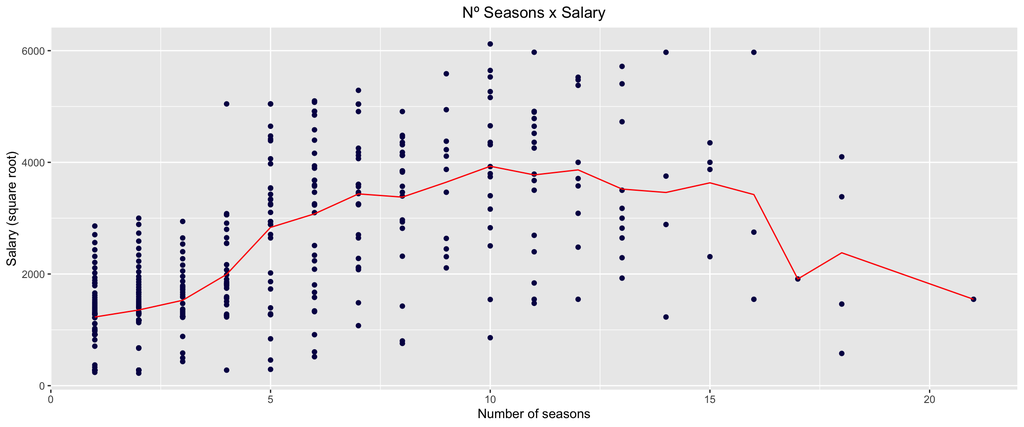

This graph shows the distribution of salaries according to the number of seasons in the NBA and the trend that these values follow. We can see that the salary of the NBA players increases until 10 seasons and then it starts to decrease. So the more seasons played doesn’t mean higher salaries. Aditionally, in the number of seasons in which the mean salary is higher, the SD is higher too, so there is not a clear tendency.

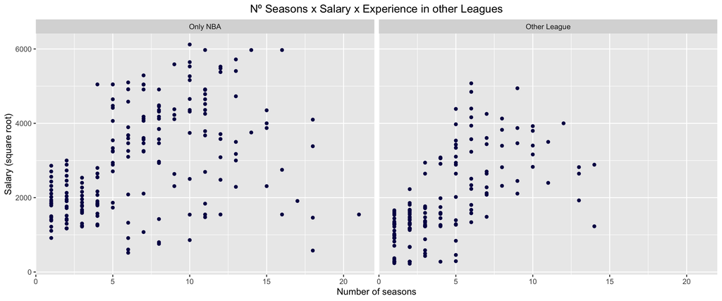

If we split the first graph by the Experience in other Leagues (usually foreign players) we observe from only NBA players plot that there is no big correlation between number of seaons and as the data is scattered. Nevertheless, the salaries from other leagues players follow a linear trend, the data is less scattered, in spite of the fact that the highest salaries belong to NBA players, and the mean of the salaries of a new player in NBA is lower if the player comes from other league.

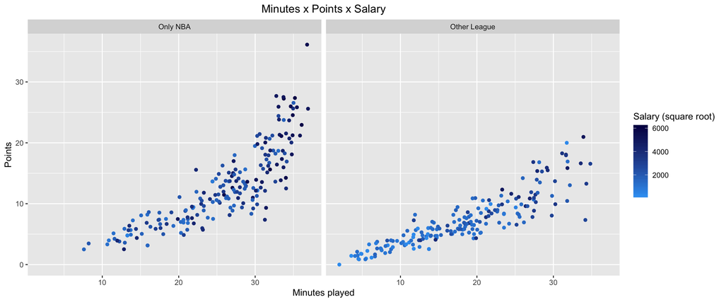

This chart compares the performance and salary of national and foreign players. The players that only have played in NBA have greater salaries and their points/minutes ratio follow an exponentional tendency. On the other hand, the players with experience in other leagues has lower salaries in general and their performance follows a linear trend. In this case, the number of points per match is very well correlated with the minutes played. We can observe that the highest salaries belong to the players with more minutes played, although in the players who come from NBA, the highest salaries are distributed all along the players.

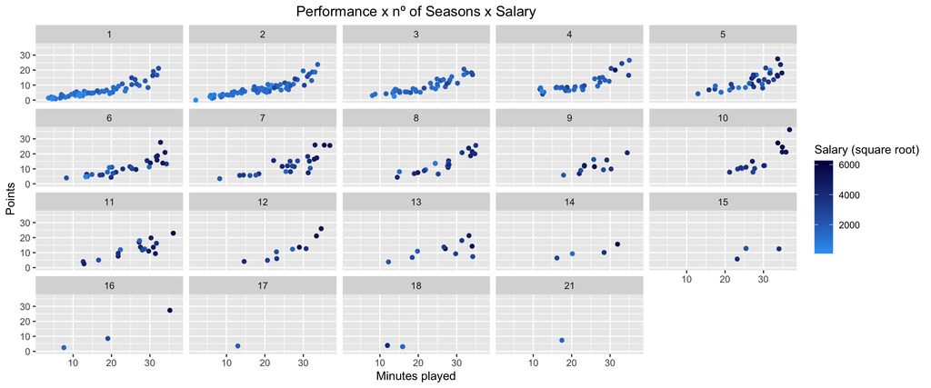

This set of graphs show how performance and salary evolves over the seasons. It is clear that there are more players with few seasons (between 1 and 6) and that they are the ones who earn less money. As they have more experience their salary increases along with their performance, because they play more minutes and the points/minute ratio follows a much steeper trend. In all the graphs in which we have enough data we infer that the more minutes played, the more points are scores, as it may sound obvious.

### Machine Learning model

We want to create a ML model which can predict the salary of a player taking into account various features extracted from the season 2019-2019 statistic. At the end, the scope of this model is to predict how much could earn a player from another league if he moves to the NBA. First of all, because the Salary is a really high number (some players received over 35 million dollars), we decided to transform the response variable to the percentage of the salary compared with the whole payroll of the NBA.

To explore which features are related with our outcome interest, we opted to obtain the correlation matrix of our dataset.

|  | winrate | minutes | pts | ast | plusminus | blk |
| --- | --- | --- | --- | --- | --- | --- |
| winrate | 1.0000000 | -0.1197332 | -0.0294307 | 0.0112185 | 0.6636000 | 0.0309445 |
| minutes | -0.1197332 | 1.0000000 | 0.8583571 | 0.6621474 | 0.2286116 | 0.3274656 |
| pts | -0.0294307 | 0.8583571 | 1.0000000 | 0.6616061 | 0.2816921 | 0.3211487 |
| ast | 0.0112185 | 0.6621474 | 0.6616061 | 1.0000000 | 0.2639641 | 0.0382138 |
| plusminus | 0.6636000 | 0.2286116 | 0.2816921 | 0.2639641 | 1.0000000 | 0.1743208 |
| blk | 0.0309445 | 0.3274656 | 0.3211487 | 0.0382138 | 0.1743208 | 1.0000000 |

The full matrix cannot be displayed on this report because it has so many elements. Anyways, we’re only interested on the correlations with the response variable, so we will only pick the row of the matrix were these correlations are displayed

|  | x |
| --- | --- |
| pctSalaryTotal | 1.0000000 |
| pts | 0.6236917 |
| fgm | 0.6111903 |
| fga | 0.6063705 |
| minutes | 0.5841820 |
| ftm | 0.5826745 |
| countSeasons | 0.5824936 |
| tov | 0.5749475 |
| fg2a | 0.5581267 |
| fg2m | 0.5495045 |
| dreb | 0.5310308 |
| ast | 0.5215779 |
| stl | 0.4965554 |
| treb | 0.4862801 |
| plusminus | 0.3542838 |
| pf | 0.3350855 |
| oreb | 0.2849184 |
| blk | 0.2582796 |
| pctFG3 | 0.1882979 |
| pctFG | 0.1833022 |
| winrate | 0.1031343 |

Having selected the features to be included in the formula, we have a formula with 10 features. To split the data we’re going to set a seed and set the partition rate on 80/20 for training and testing.

```r
set.seed(2403)
ml_data <- pre_ml_data %>%
  select(pts, fgm, minutes, ftm, countSeasons, tov, fg2m, dreb, ast, stl, pctSalaryTotal)

trainIndex <- createDataPartition(ml_data$pctSalaryTotal, p = .8, list = FALSE, times = 1)

training_set <- ml_data[ trainIndex, ]
test_set <- ml_data[ -trainIndex, ]
```

Once we have the data splitted, we have to set our model. We chose a Parallel Random Forest, provided in the `caret` package because is the one of the most accurate machine learning algorithms available nowadays.

```r
fitControl <- trainControl(
  method = "repeatedcv",
  number = 10,
  repeats = 3
)

tune_grid <- expand.grid(.mtry = c(1:10))

model_fit <- train(pctSalaryTotal ~ .,
                   data = ml_data,
                   method = "parRF", # Parallel Random Forest
                   preProcess="scale",
                   importance = T,
                   trControl = fitControl,
                   tuneGrid = tune_grid,
                   na.action = na.exclude)
model_preds <- predict(model_fit, test_set)
```

### Results

Once the model has been fit, we can check the different `mtry` values tested and how they performed.

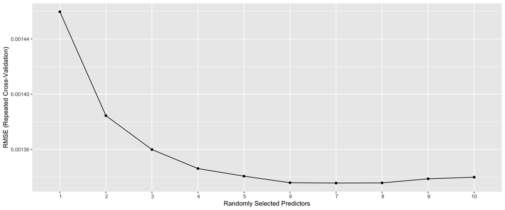

As we can see in the graph, the best `mtry` is 7, with a RMSE of 0.001333431.

With this results we could provide a quite accurate prediction of their salaries to players from other leagues who want to move to the NBA. Anyways, they’d have to wait for some years to take into account this prediction since the first years the salary is totally conditioned by the position in the draft.

### Discussion and Future Work

To understand the implications this model may have in the world of the NBA, one must understand the economic workings of the organization itself. As we have mentioned in some points of the work, the first year of a player in his passage through the NBA means the entrance in the DRAFT.

The DRAFT is a procedure that takes place at the end of June every year, by which the franchises incorporate players under 23 years old to their teams, coming from American universities or from other countries’ leagues. This at a salary level implies that the player, depending on his position within the DRAFT, receives a higher monetary amount the higher he is on the list.

Therefore, as far as predicting first year players is concerned, we could not know an approximation of their salary. Therefore, our focus would be on players who have been in the NBA for more than one season. Then, the purpose of the model would be that NBA teams could apply an economic plan being able to predict what money they will spend next season on new players based on their statistics. Since franchises in the NBA have a defined seasonal salary limit to pay their players, being able to approximate at an economic level which players they would have available would be a great strategic advance.

As future work related to this approximation of the salary of a player for the next season, we would find in the first place, as we mentioned previously, the creation of an application that with the help of this model and some additional recommendation algorithm, of a competitive strategy in terms of transfers and future team to the franchises. Doing so, that each franchise with this tool can make a plan for the future to try to get a substantial improvement of their statistics per game and make them dream of becoming champions of their conference, and even to be league champions.